# Homework

### Chapter 1 Questions

For this problem set, we will use 13103 observations of hourly counts from 2011 to 2012 for bike rides (rentals) from the Capital Bikeshare system in Washington DC. The data are recorded for hours after 6am every day (we omit earlier hours for convenience since they often include zero ride counts). This dataset was originally compiled by Fanaee and Gama in ‘Event labeling combining ensemble detectors and background knowledge’ (2013).

`bikeshare.csv` contains:

- `season`: 1:spring, 2:summer, 3:fall, 4:winter
- `yr`: year (0:2011, 1:2012)
- `mnth`: month (1 to 12)
- `hr`: hour (6 to 23)
- `holiday`: whether day is holiday or not
- `weekday`: day of the week, counting from 0:sunday.
- `notbizday`: if day is either weekend or holiday is 1, otherwise is 0.
- `weathersit`:
  1. Clear, Few clouds, Partly cloudy, Partly cloudy
  2. Mist + Cloudy, Mist + Broken clouds, Mist + Few clouds, Mist
  3. Light Snow, Thunderstorm + Scattered clouds, Light Rain + Scattered clouds
  4. Heavy Rain + Ice Pallets + Thunderstorm + Mist, Snow + Fog
- `temp`: Temperature, measured in standard deviations from average.
- `hum`: Humidity, measured in standard deviations from average.
- `windspeed`: Wind speed, measured in standard deviations from average.
- `dteday`: date
- `cnt`: count of total rental bikes

**Read the bikeshare data into R. Plot the marginal distribution for the count of bike rentals and the conditional count distribution given the hour of day.**

```r
biketab <- read.csv("bikeshare.csv")
head(biketab)
```

|  | season | yr | mnth | hr | holiday | weekday | notbizday | weathersit | temp | hum | windspeed | dteday | cnt |
| --- | --- | --- | --- | --- | --- | --- | --- | --- | --- | --- | --- | --- | --- |
| 1 | 1 | 0 | 1 | 6 | 0 | 6 | 1 | 1 | -1.4384750 | 0.8955129 | -1.5538438 | 2011-01-01 | 2 |
| 2 | 1 | 0 | 1 | 7 | 0 | 6 | 1 | 1 | -1.5423408 | 1.2065068 | -1.5538438 | 2011-01-01 | 3 |
| 3 | 1 | 0 | 1 | 8 | 0 | 6 | 1 | 1 | -1.3346092 | 0.6363514 | -1.5538438 | 2011-01-01 | 8 |
| 4 | 1 | 0 | 1 | 9 | 0 | 6 | 1 | 1 | -0.9191459 | 0.6881837 | -1.5538438 | 2011-01-01 | 14 |
| 5 | 1 | 0 | 1 | 10 | 0 | 6 | 1 | 1 | -0.6075484 | 0.6881837 | 0.5198813 | 2011-01-01 | 36 |
| 6 | 1 | 0 | 1 | 11 | 0 | 6 | 1 | 1 | -0.7114142 | 0.9473452 | 0.7642817 | 2011-01-01 | 56 |

[figure not shown]

```r
par(mfrow=c(1,2))
hist(biketab$cnt, xlab="hourly ride count", freq=FALSE, main="")
boxplot(biketab$cnt ~ biketab$hr, xlab="hour of day", ylab="hourly ride count")
```

**Fit a regression for hourly ride count as a function of the weather situation variable. What is the difference in expected ride counts when the weather is clear (`weathersit=1`) vs rain or snow (`weathersit=4`)?**

First we need to make sure that the weather situation is treated by R as a factor variable.

```r
biketab$weathersit <- factor(biketab$weathersit)
levels(biketab$weathersit)
```

```
[1] "1" "2" "3" "4"
```

Next, use GLM to regress the counts onto the weather situation.

```r
wsfit <- glm(cnt ~ weathersit, data=biketab)
summary(wsfit)
```

```
Call:
glm(formula = cnt ~ weathersit, data = biketab)

Deviance Residuals:
   Min      1Q  Median      3Q     Max
-262.8  -124.8   -41.8    86.2   750.8

Coefficients:
            Estimate Std. Error t value Pr(>|t|)
(Intercept)  263.797      1.881 140.233   <2e-16 ***
weathersit2  -39.275      3.523 -11.149   <2e-16 ***
weathersit3 -123.605      5.587 -22.122   <2e-16 ***
weathersit4 -163.797    123.232  -1.329    0.184
---
Signif. codes:  0 ‘***’ 0.001 ‘**’ 0.01 ‘*’ 0.05 ‘.’ 0.1 ‘ ’ 1

(Dispersion parameter for gaussian family taken to be 30365.39)

    Null deviance: 414271583  on 13102  degrees of freedom
Residual deviance: 397756252  on 13099  degrees of freedom
AIC: 172428

Number of Fisher Scoring iterations: 2
```

We see that weather situation 1 is the reference level, with an expected ride count of 264 rides per hour. Weather situation 4 has an expected *164 fewer rides per hour*.

**What are the in-sample SSE, R2, and an estimate of the standard deviation of the residual errors for the ride-weather regression that you just ran?**

From the `summary.glm` output, the SSE is 397756252, the R2 is 0.04:

```r
1- 397756252/414271583
```

```
[1] 0.03986595
```

And the residual error variance is 30365.39 (the “dispersion parameter”) so the standard error is around 174.

```r
sqrt(30365.39)
```

```
[1] 174.2567
```

**Plot the residual errors from your ride-weather regression. Do they appear like they come from a Gaussian distribution? If not, what transformation should we consider using in our regression model?**

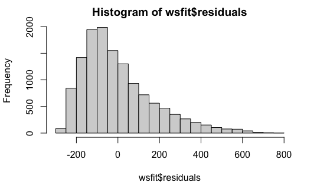

```r
hist(wsfit$residuals)
```

Nope, they do not look Gaussian. We should consider a log transformation on the response.

**We are now going to add more input variables and transform the response. Fit a log-linear regression for the log hourly ride counts onto all of the weather variables (`weathersit`, `temp`,`hum`,`windspeed`). You can ignore the date/time variables for now. Recalling that the continuous variables are measured in terms of standard deviation above average, what is the increase in average ride counts due to a 1 SD increase in the temperature?**

First, fit the model

```r
weatherfit <- glm(log(cnt) ~ weathersit + temp + hum + windspeed, data=biketab)
summary(weatherfit)
```

```
Call:
glm(formula = log(cnt) ~ weathersit + temp + hum + windspeed,
    data = biketab)

Deviance Residuals:
    Min       1Q   Median       3Q      Max
-4.8630  -0.4223   0.0461   0.4982   2.1367

Coefficients:
             Estimate Std. Error t value Pr(>|t|)
(Intercept)  5.140073   0.009022 569.715  < 2e-16 ***
weathersit2  0.046526   0.016446   2.829  0.00468 **
weathersit3 -0.421729   0.027234 -15.485  < 2e-16 ***
weathersit4  0.051010   0.538808   0.095  0.92458
temp         0.411902   0.006605  62.365  < 2e-16 ***
hum         -0.168119   0.007885 -21.322  < 2e-16 ***
windspeed   -0.013933   0.006872  -2.027  0.04263 *
---
Signif. codes:  0 ‘***’ 0.001 ‘**’ 0.01 ‘*’ 0.05 ‘.’ 0.1 ‘ ’ 1

(Dispersion parameter for gaussian family taken to be 0.5798544)

    Null deviance: 10881.3  on 13102  degrees of freedom
Residual deviance:  7593.8  on 13096  degrees of freedom
AIC: 30053

Number of Fisher Scoring iterations: 2
```

The coefficient on `temp` is 0.4119, and exponentiating gives you the multiplier on expected ride counts.

```r
exp(0.4119)
```

```
[1] 1.509683
```

Ride counts increase by around 50% per every one standard deviation increase in the temperature.

**Interact the temperature with the `weathersit` variable. What is the change in expeced ride count per 1SD increase in temperature when it is wet or snowy outside (`weathersit=4`).**

```r
coef(weatherfit2)
```

[output not shown]

[output not shown]